```python
import numpy as np
import pandas as pd
import matplotlib.pyplot as plt
import matplotlib.image as mpimg
from sklearn.decomposition import PCA
from plotnine import *
from sklearn.preprocessing import StandardScaler
```

# Introduction

I elected to reproduce figures from a 2025 paper by Gao et al. that investigates prognostic indicators of endometrial carcinoma (EC) [1]. EC is the most common malignancy of the female reproductive tract and the fourth most common cancer among women [2]. Accurate prognostic evaluation is critical for advancing precision medicine approaches and developing informed treatment plans that balance therapeutic efficacy with risk and invasiveness. Gao et al. argue that existing prognostic biomarkers of EC remain limited in predictive capacity and thus require further exploration. To address this, the authors applied a series of bioinformatics and statistical analyses to a publicly available EC microarray dataset from the Gene Expression Omnibus (GEO accession GSE120490). This dataset consists of normalized expression profiles from 145 primary EC tumor samples annotated for metastatic status, tumor grade, and microsatellite instability. Gao et al.'s analysis pipeline includes differential expression analysis to identify genes associated with metastatic potential, followed by downstream modeling approaches intended to relate gene expression patterns to patient prognosis [1].

For my project, I focus on reproducing (i) the principal component analysis (PCA) used to visualize separation between metastatic and non-metastatic samples based on gene expression profiles and (ii) the volcano plot depicting fold change and statistical significance of differentially expressed genes. I initially selected this paper because it uses publicly available data, employs analytical methods covered in class, and addresses a disease area I'm interested in. However, as I progressed in reproducing the figures, I uncovered several inconsistencies and ambiguities in the authors’ methods, claims, and interpretations of the dataset. While these issues limit the robustness of the paper’s conclusions, the replication process itself still proved highly valuable for me, as it highlighted the importance of careful data interpretation and critical evaluation of methods and claims when analyzing bioinformatics experiments.

# Methods

### Pre-processing

All data pre-processing was performed in R (v4.4.0) using an R Markdown workflow (preprocess.Rmd). First, I used the *getGEO* function from GEOquery (v2.74.0) to download the GEO dataset (accession GSE120490). From the GEO object, I extracted the sample metadata table and the normalized expression matrix. Next, I used the GPL570 platform annotation to perform probe-to-gene annotation [4]. Gene symbols were appended to the corresponding rows of the expression matrix based on probe mappings. Some microarray probes map to multiple genes, so I created separate rows for each probe–gene relationship to retain all annotated genes. Additionally, multiple probes map to the same gene symbol, so I collapsed probe-level expression values to the gene level by keeping the probe with the maximum mean expression across samples for each gene.

### Differential Expression Analysis

Differential expression analysis was performed on the gene-level expression matrix using the limma package (v3.62.2). Linear models were fitted for each gene using the *lmfit* function, with contrasts specified using *contrasts.fit*. Empirical Bayes moderation was applied using the *eBayes* function to improve variance estimates and compute moderated t-statistics. Differentially expressed genes were identified using the *topTable* function, with p-values adjusted for multiple testing using the Benjamini–Hochberg false discovery rate (FDR) correction [3].

Although the reference study claims to have performed differential expression analysis between tumor and normal tissues, the GSE120490 dataset contains only tumor samples [1]. Therefore, I evaluated differential expression using available clinical annotations, including metastatic status, tumor grade, and microsatellite instability. Among these, stratification by metastatic status most closely reproduced the reported results, so I used it for all downstream analyses. Output files generated from this R workflow include the sample metadata, gene-level expression matrix, and differential expression results.

### PCA Recreation

I used scikit-learn (v1.7.2) to reproduce Gao et al.'s PCA plot. The unmodified expression matrix from GEO was used as input. The matrix was transposed so that rows corresponded to samples and columns to genes, and features were centered and standardized using *StandardScaler*. PCA was then computed using scikit-learn’s *PCA* function, and the first two principal components were extracted. I also stored the proportion of variance explained by each component to be included in plot axis labels [5]. To enable plotting, PCA scores for each sample were first combined with sample metadata into a single dataframe. The sign of PC2 was flipped to match the orientation of Gao et al's figure. PCA plots were generated using the plotnine package to enable ggplot-style rendering in Python. Samples were colored by metastatic status, with 95% confidence ellipses added to match the original figure. The PCA plot was exported as a PNG file so that I could display it next to Gao et al's figure [6].

### Volcano Plot Recreation

To reproduce their volcano plot, I first read in my differential expression results and saved it as a dataframe. I added columns to the dataframe corresponding to log2FC and -log10(p-value) to match the plotting conventions used by Gao et al. I then assigned colors the same as they did, making genes with log2FC > 1 red, those with log2FC < -1 blue, and all others grey. I used matplotlib to render my volcano plot alongside Gao et al.'s figure [7].

## Results

### PCA Recreation

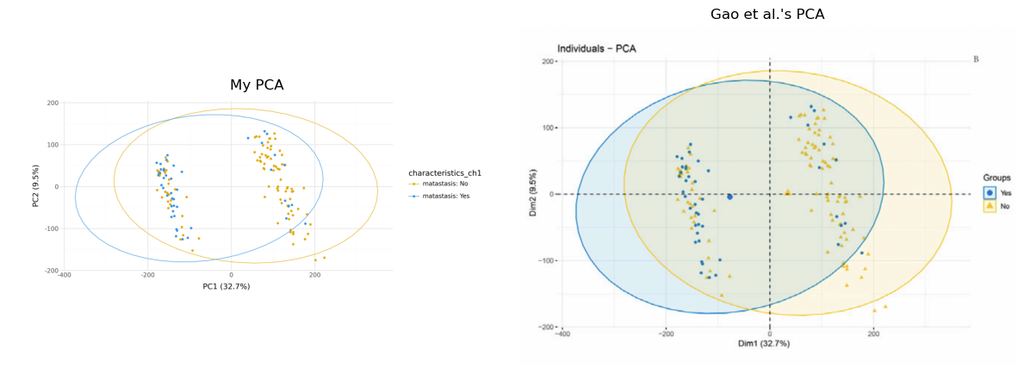

```python
# Read in expression data
ex = pd.read_csv("expression_matrix.csv", index_col=0)

# Transpose expression matrix so it is samples x genes
ex_t = ex.T

# Read in metadata
meta = pd.read_csv("gset_pheno.csv", index_col=0)
meta.index = meta.index.astype(str)

# Standardize data
scaler = StandardScaler()
ex_t_scaled = scaler.fit_transform(ex_t)

# Compute PCA
pca = PCA(n_components=2)
scores = pca.fit_transform(ex_t_scaled)

# Explained variance percentages
var_expl = pca.explained_variance_ratio_
pc1_perc = round(var_expl[0] * 100, 1)
pc2_perc = round(var_expl[1] * 100, 1)

# Create df to store PC1 and PC2
plot_df = pd.DataFrame(scores, columns=['PC1', 'PC2'], index=ex_t.index)
plot_df['Sample'] = plot_df.index

# Merge df with metadata
plot_data = plot_df.merge(meta, left_on='Sample', right_index=True)

# Flip PCA so it matches the paper
plot_data['PC2'] *= -1

# Create PCA plot, colored by metastatic status, with stat ellipses (like in paper)
custom_colors = {
    'matastasis: No': '#e3aa0e',
    'matastasis: Yes': '#3695e3'
}

p = (
    ggplot(plot_data, aes(x='PC1', y='PC2', color='characteristics_ch1', fill='characteristics_ch1')) +
    geom_point(size=1) +
    stat_ellipse(type='norm', alpha=0.8) +
    theme_minimal() +
    coord_fixed(ratio=1) +
    labs(
        x=f'PC1 ({pc1_perc}%)',
        y=f'PC2 ({pc2_perc}%)',
    ) +
    scale_color_manual(values=custom_colors) +
    scale_fill_manual(values=custom_colors)
)
p.save("my_pca.png", width=10, height=4, dpi=400)

# Load images
my_img = mpimg.imread("my_pca.png")
their_img = mpimg.imread("their_pca.png")

# Plot side by side
fig, axes = plt.subplots(1, 2, figsize=(12, 6))
axes[0].imshow(my_img)
axes[0].axis('off')
axes[0].set_title("My PCA")

axes[1].imshow(their_img)
axes[1].axis('off')
axes[1].set_title("Gao et al.'s PCA")

plt.tight_layout()
plt.show()
```

### PCA Results

My PCA is effectively identical to Gao et al.'s. First, we both found that PC1 explains 32.7% of the total variance in gene expression, while PC2 explains 9.5%. The projection of samples onto these components reveals two broad clusters separated primarily along PC1. The majority of non-metastatic samples fall into the right cluster, and the majority of metastatic samples fall into the left cluster. Gao et al.'s PCA depicts an unexplained larger blue circle and yellow triangle between the two clusters, which I think are likely unintentional artifacts.

The caption associated with Gao et al.’s PCA states that sample grouping represents “endometrial cancer tissue” versus “normal endometrial tissue.” However, the GSE120490 dataset does not include normal endometrial samples, as all profiles correspond to tumor tissue. The fact that I was able to identically recreate their figure by coloring samples according to metastatic status strongly suggests that metastatic status was likewise used in their figure.

Independent of labeling inconsistencies, the PCA reveals meaningful biological structure in the dataset. As discussed in class, PCA projects high-dimensional data onto the two vectors that capture the largest sources of variation across samples. The observed clustering demonstrates that there is a major transcriptional axis dividing tumors into two broad expression states. While metastatic samples are more frequently observed in one cluster and non-metastatic samples in the other, substantial overlap exists between groups. This indicates that metastatic status is associated with, but does not fully define, the major axis of transcriptional variation observed in this PCA.

Non-metastatic samples existing within the metastatic-enriched left cluster could represent tumors with aggressive transcriptional profiles, which could have the potential to metastasize later. Conversely, metastatic samples within the right cluster may represent tumors that metastasized via alternative mechanisms or exhibit expression profiles that are otherwise typical of less aggressive disease. Together, these results suggest that metastasis biases tumors toward specific expression states but does not constitute a discrete transcriptional class, underscoring the biological heterogeneity of endometrial carcinoma.

### Volcano Plot Recreation

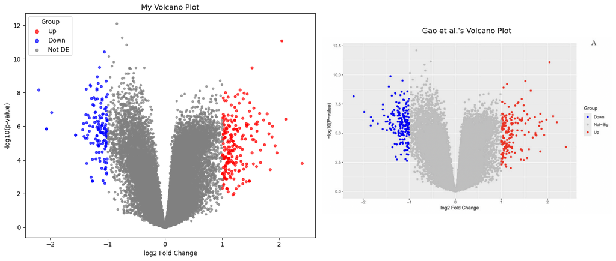

```python
# Read in differential expression data
deg = pd.read_csv("deg_results.csv", index_col=0)

# Prepare columns for plotting
deg['log2FC'] = deg['logFC']
deg['negLog10P'] = -np.log10(deg['P.Value'])

# Assign colors
deg['color'] = np.where(deg['log2FC'] > 1, 'red', np.where(deg['log2FC'] < -1, 'blue', 'grey'))

# Set figure size
fig, axes = plt.subplots(1, 2, figsize=(14,6))

# Plot points by color
for col, label in zip(['red', 'blue', 'grey'], ['Up', 'Down', 'Not DE']):
    subset = deg[deg['color'] == col]
    axes[0].scatter(
        subset['log2FC'],
        subset['negLog10P'],
        c=col, label=label, alpha=0.7, s=10 if col=='grey' else 15
    )

# Add axis labels and legend
axes[0].set_xlabel("log2 Fold Change")
axes[0].set_ylabel("-log10(p-value)")
axes[0].legend(title="Group", markerscale=1.5)
axes[0].set_title("My Volcano Plot")

# Display their volcano plot beside mine
their_img = mpimg.imread("their_volcano.png")

axes[1].imshow(their_img)
axes[1].axis('off')
axes[1].set_title("Gao et al.'s Volcano Plot")

plt.tight_layout()
plt.show()
```

### Volcano Plot Results

My volcano plot closely resembles that reported by Gao et al., with overall conservation of structure and signal. In both plots, the right plume is broader and more horizontally dispersed, whereas the left plume is generally taller and more compact. Several prominent differentially expressed genes appear in both figures, including a strongly upregulated gene with a log2 fold change of around 2 and a -log10(p-value) around 11, as well as a downregulated gene with a log2 fold change of around -2.2 and a -log10(p-value) just over 8.

That said, the two volcano plots do not match exactly. For instance, my plot is missing many of the genes between -1.5 and -2 log2 fold change depicted in Gao et al.'s figure. These discrepancies likely reflect differences in preprocessing and analytical implementation. In particular, the paper does not document how probes mapping to multiple genes were handled, nor how multiple probes per gene were collapsed prior to gene-level differential expression analysis. I explored alternative collapsing strategies, such as taking the mean or median probe expression rather than the max, but such methods did not substantially alter the observed similarity. Additionally, Gao et al. report having normalized the raw data prior to differential expression analysis, yet they do not specify how this normalization was performed. Since each GSE120490 sample is annotated as having been normalized using the RMA algorithm, I elected not to perform further normalization. Minor differences in limma model configuration may also contribute to variation between results.

Independent of these discrepancies, my volcano plot provides biologically meaningful insight into the dataset. The presence of numerous significantly differentially expressed genes in both directions of the figure suggests that metastatic status is associated with widespread transcriptional changes rather than isolated effects from a small number of genes, which is consistent with the global expression patterns depicted in my PCA. Moreover, the asymmetry depicted in the volcano plot is worth noting—particularly that the right plume is broader and more abundant at higher fold changes than the left plume. This suggests that metastatic tumors may activate expression programs more than they repress them, although this interpretation is qualitative rather than mechanistic.

Together with the PCA results, the volcano plot indicates that the acquisition of metastatic potential in endometrial carcinoma is transcriptionally heterogeneous and likely driven by alterations in multiple gene-expression programs.

## References:

1. Gao, L., Yuan, D., Huang, A., & Qian, H. (2025). Bioinformatics-based identification of differentially expressed genes in endometrial carcinoma: Implications for early diagnosis and prognostic stratification. Frontiers in Genetics, 16, Article 1631060. https://doi.org/10.3389/fgene.2025.1631060
2. American Cancer Society. (2025, May 30). Key statistics for endometrial cancer. https://www.cancer.org/cancer/types/endometrial-cancer/about/key-statistics.html
3. Ritchie, M. E., Phipson, B., Wu, D., Hu, Y., Law, C. W., Shi, W., & Smyth, G. K. (2015). limma powers differential expression analyses for RNA-sequencing and microarray studies. Nucleic Acids Research, 43(7), e47. https://doi.org/10.1093/nar/gkv007
4. Davis, S., & Meltzer, P. S. (2007). GEOquery: A bridge between the Gene Expression Omnibus (GEO) and BioConductor. Bioinformatics, 23(14), 1846–1847. https://doi.org/10.1093/bioinformatics/btm254
5. Pedregosa, F., Varoquaux, G., Bertrand, T., Grisel, O., Blondel, M., Prettenhofer, P., Weiss, R., Dubourg, V., Vanderplas, J., Passos, A., Cournapeau, D., Brucher, M., Perrot, M., & Duchesnay, É. (2011). Scikit-learn: Machine learning in Python. Journal of Machine Learning Research, 12, 2825–2830.
6. Kibirige, H. (n.d.). plotnine: A grammar of graphics for Python [Computer software]. https://github.com/has2k1/plotnine
7. Hunter, J. D. (2007). Matplotlib: A 2D graphics environment. Computing in Science & Engineering, 9(3), 90–95. https://doi.org/10.1109/MCSE.2007.55